# Исследование объявлений о продаже квартир

#### check gap

```python
# check
data.info()
```

```
<class 'pandas.core.frame.DataFrame'>
Int64Index: 23696 entries, 0 to 23698
Data columns (total 28 columns):
 #   Column                Non-Null Count  Dtype
---  ------                --------------  -----
 0   total_images          23696 non-null  int64
 1   last_price            22269 non-null  float64
 2   total_area            23132 non-null  float64
 3   first_day_exposition  23696 non-null  datetime64[ns]
 4   rooms                 23501 non-null  float64
 5   ceiling_height        14143 non-null  float64
 6   floors_total          23664 non-null  float64
 7   living_area           20045 non-null  float64
 8   floor                 23696 non-null  int64
 9   is_apartment          23696 non-null  bool
```

[output cut: 20 more lines]

```python
# check

# Показатели о кол-ве объявлений в датасете, минимальных и максимальных значениях
# в выбранных параметрах о продаже квартир
# сырые данные

(
    data[['rooms', 'total_area', 'ceiling_height', 'days_exposition', 'last_price', 'living_area',  'kitchen_area',
          'floor', 'floors_total']]
    .apply (['count', 'min', 'max', 'median'])
    .style.format("{:,.2f}")
)
```

|  | rooms | total_area | ceiling_height | days_exposition | last_price | living_area | kitchen_area | floor | floors_total |
| --- | --- | --- | --- | --- | --- | --- | --- | --- | --- |
| count | 23,501.00 | 23,132.00 | 14,143.00 | 20,460.00 | 22,269.00 | 20,045.00 | 20,290.00 | 23,696.00 | 23,664.00 |
| min | 1.00 | 12.00 | 2.50 | 3.00 | 1.00 | 12.00 | 5.00 | 1.00 | 1.00 |
| max | 5.00 | 150.00 | 3.50 | 1,299.00 | 15.00 | 60.00 | 20.00 | 33.00 | 29.00 |
| median | 2.00 | 51.00 | 2.65 | 95.00 | 4.50 | 29.50 | 9.00 | 4.00 | 9.00 |

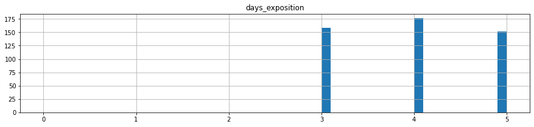

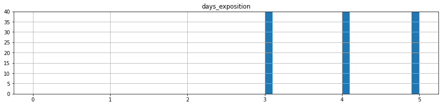

```python
# check
data.hist(column = 'days_exposition', bins = 50, figsize = (15,3), range = (0,5));

data.hist(column = 'days_exposition', bins = 50, figsize = (15,3), range = (0,5))
plt.ylim(0, 40);
```

```python
# check

try:
    df_check = pd.read_csv('https://code.s3.yandex.net/datasets/real_estate_data.csv', sep='\t')
# если не получилось прочитать файл из локальной папки, то загружаем данные из сети
except:
    df_check = pd.read_csv('real_estate_data.csv', sep='\t')
```

```python
# check
df_check.rooms.value_counts().to_frame()
```

|  | rooms |
| --- | --- |
| 1 | 8047 |
| 2 | 7940 |
| 3 | 5814 |
| 4 | 1180 |
| 5 | 326 |
| 0 | 197 |
| 6 | 105 |
| 7 | 59 |
| 8 | 12 |
| 9 | 8 |
| 10 | 3 |
| 11 | 2 |
| 14 | 2 |
| 19 | 1 |
| 16 | 1 |
| 12 | 1 |
| 15 | 1 |

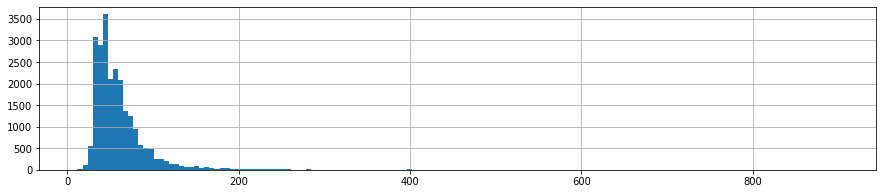

```python
# check
df_check.total_area.hist(bins = 150, figsize = (15,3));
```

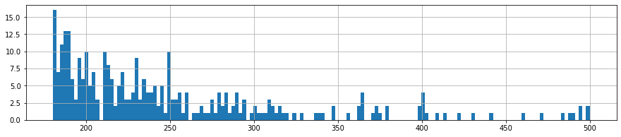

```python
# check
df_check.total_area.hist(bins = 150, figsize = (15,3), range = (180,500));
```

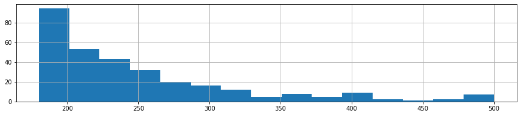

```python
# check
df_check.total_area.hist(bins = 15, figsize = (15,3), range = (180,500));
```

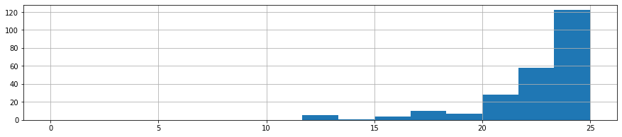

```python
# check
df_check.total_area.hist(bins = 15, figsize = (15,3), range = (0,25));
```

```python
# check

# Значения параметров объектов недвижимости на разных квантилях

(
    data[['rooms', 'total_area', 'ceiling_height', 'days_exposition', 'last_price', 'living_area',
        'kitchen_area', 'floor',   'floors_total']]
    .quantile([0.0012, 0.01, .5, .99, .9988]) # выбираем размах в 0,9976 квантилей
    .style.format("{:,.2f}")
)
```

|  | rooms | total_area | ceiling_height | days_exposition | last_price | living_area | kitchen_area | floor | floors_total |
| --- | --- | --- | --- | --- | --- | --- | --- | --- | --- |
| 0.0012 | 1.00 | 20.00 | 2.50 | 3.00 | 1.05 | 12.00 | 5.00 | 1.00 | 2.00 |
| 0.01 | 1.00 | 25.00 | 2.50 | 4.00 | 1.30 | 14.00 | 5.00 | 1.00 | 2.00 |
| 0.5 | 2.00 | 51.00 | 2.65 | 95.00 | 4.50 | 29.50 | 9.00 | 4.00 | 9.00 |
| 0.99 | 5.00 | 133.40 | 3.46 | 1,012.41 | 14.00 | 58.00 | 19.20 | 23.00 | 26.00 |
| 0.9988 | 5.00 | 149.00 | 3.50 | 1,225.45 | 15.00 | 60.00 | 20.00 | 26.00 | 27.00 |

#### Изучение скорости продажи квартир

```python
# Проверка данных в столбце days_exposition
print(f'median: {data["days_exposition"].median()}')
data['days_exposition'].describe()
```

```
median: 95.0
```

```
count    20460.000000
mean       177.841935
std        211.282025
min          3.000000
25%         45.000000
50%         95.000000
75%        230.000000
max       1299.000000
Name: days_exposition, dtype: float64
```

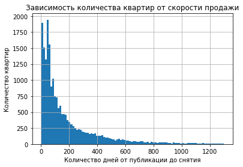

```python
data['days_exposition'].plot(
    title='Зависимость количества квартир от скорости продажи',
    kind='hist',
    bins=100,
    grid=True
)
plt.xlabel('Количество дней от публикации до снятия')
plt.ylabel('Количество квартир')
```

```python
data['days_exposition'].value_counts().head()
```

```
45.0    880
60.0    538
7.0     234
30.0    208
90.0    204
Name: days_exposition, dtype: int64
```

```python
# скорость продажи квартир по годам
data.pivot_table(index='year', values='days_exposition', aggfunc=['median', 'count'])
```

| year | median days_exposition | count days_exposition |
| --- | --- | --- |
| 2014 | 781.0 | 103 |
| 2015 | 563.0 | 1085 |
| 2016 | 235.0 | 2716 |
| 2017 | 103.0 | 7919 |
| 2018 | 64.0 | 7558 |
| 2019 | 24.0 | 1079 |

**Вывод:**

- Пики на 45, 60 и 90 дне объявняются условиями публикации объявлений. 45, 60 и 90 - это максимальные сроки публикации квартир. После этого объявления снимаются автоматически;
- Медианое значение времени продажи квартиры - 95 дней. Несмотря на это, среднее - 180, но оно сильно зависит от нестандартных значений;
- Среднее время продажи квартир от 1.5 до 3 месяцев;
- Быстрыми можно считать продажи за 7-30 дней, а необычно долгие 231 день;
- С 2016 по 2019 год объявления стали снимать с публикации быстрее.

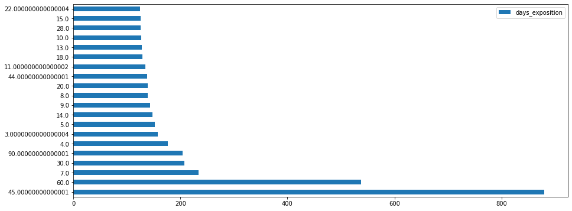

```python
# check
# Моды на сырых данных

df_check['days_exposition'].value_counts().to_frame().head(20).plot(kind = 'barh', figsize = (15,6), rot = 0);
```

#### Факторы, влияющие на общую стоимость объекта

```python
data.pivot_table(
    index=range(0, data.shape[0]),
    values=['last_price', 'total_area', 'living_area', 'kitchen_area', 'rooms', 'day_week', 'month', 'year']
).corr().round(2)
```

|  | day_week | kitchen_area | last_price | living_area | month | rooms | total_area | year |
| --- | --- | --- | --- | --- | --- | --- | --- | --- |
| day_week | 1.00 | -0.02 | -0.01 | -0.00 | 0.01 | -0.00 | -0.01 | -0.00 |
| kitchen_area | -0.02 | 1.00 | 0.52 | 0.17 | 0.02 | 0.13 | 0.50 | -0.06 |
| last_price | -0.01 | 0.52 | 1.00 | 0.55 | 0.00 | 0.49 | 0.74 | -0.01 |
| living_area | -0.00 | 0.17 | 0.55 | 1.00 | -0.01 | 0.89 | 0.88 | -0.04 |
| month | 0.01 | 0.02 | 0.00 | -0.01 | 1.00 | 0.00 | 0.01 | -0.27 |
| rooms | -0.00 | 0.13 | 0.49 | 0.89 | 0.00 | 1.00 | 0.79 | -0.06 |
| total_area | -0.01 | 0.50 | 0.74 | 0.88 | 0.01 | 0.79 | 1.00 | -0.08 |
| year | -0.00 | -0.06 | -0.01 | -0.04 | -0.27 | -0.06 | -0.08 | 1.00 |

```python
# check

# Показатели о кол-ве объявлений в датасете, минимальных и максимальных значениях
# в выбранных параметрах о продаже квартир
# сырые данные

(
    data[['rooms', 'total_area', 'ceiling_height', 'days_exposition', 'last_price', 'living_area',  'kitchen_area',
          'floor', 'floors_total']]
    .apply (['count', 'min', 'max'])
    .style.format("{:,.2f}")
)
```

|  | rooms | total_area | ceiling_height | days_exposition | last_price | living_area | kitchen_area | floor | floors_total |
| --- | --- | --- | --- | --- | --- | --- | --- | --- | --- |
| count | 23,501.00 | 23,132.00 | 14,143.00 | 20,460.00 | 22,269.00 | 20,045.00 | 20,290.00 | 23,696.00 | 23,664.00 |
| min | 1.00 | 12.00 | 2.50 | 3.00 | 1.00 | 12.00 | 5.00 | 1.00 | 1.00 |
| max | 5.00 | 150.00 | 3.50 | 1,299.00 | 15.00 | 60.00 | 20.00 | 33.00 | 29.00 |

##### Зависимость цены от общей площади

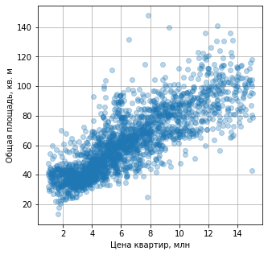

```python
data.pivot_table(index='last_price', values='total_area').plot(
    style='o',
    alpha=0.3,
    grid=True,
    figsize=(5, 5),
    legend=False
)
plt.xlabel('Цена квартир, млн')
plt.ylabel('Общая площадь, кв. м')
```

##### Зависимость цены от жилой площади

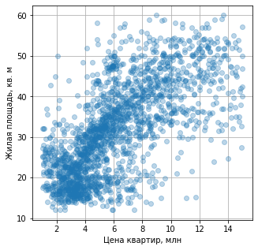

```python
data.pivot_table(index='last_price', values='living_area').plot(
    style='o',
    alpha=0.3,
    grid=True,
    figsize=(5, 5),
    legend=False
)
plt.xlabel('Цена квартир, млн')
plt.ylabel('Жилая площадь, кв. м')
```